# Load Data

```python
import pandas as pd

df_AdsPerformance = pd.read_csv('https://storage.googleapis.com/datalynn-datasets/interview-challenge/technology/Amazon_Advertising/AdsPerformance.csv')
df_AdvertiserInfo = pd.read_csv('https://storage.googleapis.com/datalynn-datasets/interview-challenge/technology/Amazon_Advertising/AdvertiserInfo.csv')
print(df_AdsPerformance.head())
print(df_AdvertiserInfo.head())
```

```
   ad_id product_id  click_count  view_count  purchase_count        date
0      1        360        107.0       161.0              12  2021-01-01
1      2        396         98.0       150.0              17  2021-01-02
2      3        168         91.0       136.0              10  2021-01-03
3      4        453        101.0       171.0               7  2021-01-04
4      5        358         97.0       144.0              11  2021-01-05
   advertiser_id  product_id  budget campaign_start campaign_end
0              1           0    2148     2021-04-11   2021-05-16
1              2           1    2694     2020-10-31   2020-12-03
2              3           2    2888     2021-01-07   2021-02-20
3              4           3    1111     2021-02-07   2021-02-26
4              5           4      65     2020-02-29   2020-04-13
```

## Question 1

**Scenario**: You've just received the `AdsPerformance` dataset, and upon initial exploration, you've found some discrepancies. You want to ensure the data is clean and standardized before any analysis.

*Question*: Identify and handle missing values, detect any outliers especially in the 'click_count' and 'view_count' columns.

First detect and handle missing.

```
ad_id              0
product_id         0
click_count       10
view_count        10
purchase_count     0
date               0
dtype: int64
```

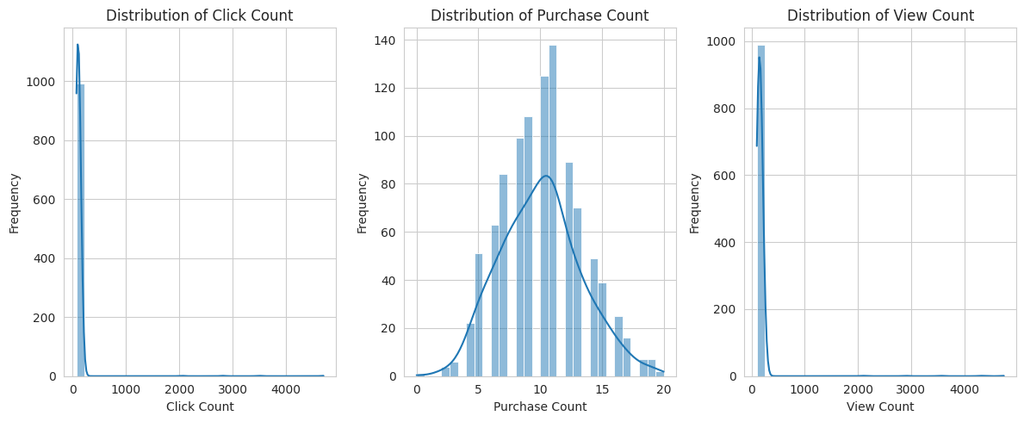

```python
import matplotlib.pyplot as plt
import seaborn as sns
import pandas as pd

# Make a copy of the original dataframe
dfp = df_AdsPerformance.copy()
# Print out the number of missing values in each column
print(dfp.isnull().sum())

# check the distribution of 'click_count' and 'purchase_count'
# Set style
sns.set_style('whitegrid')

# Plot distribution of click_count
plt.figure(figsize=(12, 5))
plt.subplot(1, 3, 1)
sns.histplot(dfp['click_count'], kde=True, bins=30)
plt.title('Distribution of Click Count')
plt.xlabel('Click Count')
plt.ylabel('Frequency')

# Plot distribution of purchase_count
plt.subplot(1, 3, 2)
sns.histplot(dfp['purchase_count'], kde=True, bins=30)
plt.title('Distribution of Purchase Count')
plt.xlabel('Purchase Count')
plt.ylabel('Frequency')

plt.subplot(1, 3, 3)
sns.histplot(dfp['view_count'], kde=True, bins=30)
plt.title('Distribution of View Count')
plt.xlabel('View Count')
plt.ylabel('Frequency')

plt.tight_layout()
plt.show()
```

Based on the distribution we plotted, it seems we might have some outliers in `click_count` and `view_count`. We can choose median to impute the missing value.

```python
# Impute missing values in click_count with its median
click_median = dfp['click_count'].median()
dfp['click_count'].fillna(click_median, inplace=True)

# Impute missing values in view_count with its median
view_median = dfp['view_count'].median()
dfp['view_count'].fillna(view_median, inplace=True)

print(dfp.isnull().sum())
```

```
ad_id             0
product_id        0
click_count       0
view_count        0
purchase_count    0
date              0
dtype: int64
```

Next, we need to detect and filter out the outliers for `click_count` and `view_count` using the IQR method.

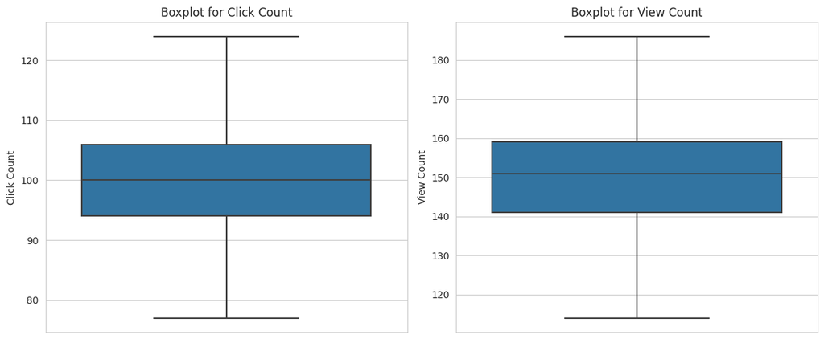

```python
# Using IQR for 'click_count'
Q1_click = dfp['click_count'].quantile(0.25)
Q3_click = dfp['click_count'].quantile(0.75)
IQR_click = Q3_click - Q1_click
outlier_range_click = [Q1_click - 1.5*IQR_click, Q3_click + 1.5*IQR_click]

# Using IQR for 'view_count'
Q1_view = dfp['view_count'].quantile(0.25)
Q3_view = dfp['view_count'].quantile(0.75)
IQR_view = Q3_view - Q1_view
outlier_range_view = [Q1_view - 1.5*IQR_view, Q3_view + 1.5*IQR_view]

# Filter out outliers
dfp = dfp[
    (dfp['click_count'] >= outlier_range_click[0]) &
    (dfp['click_count'] <= outlier_range_click[1]) &
    (dfp['view_count'] >= outlier_range_view[0]) &
    (dfp['view_count'] <= outlier_range_view[1])
]
# Creat boxplots to check the outliers again
# Set style
sns.set_style('whitegrid')

# Create side-by-side boxplots
plt.figure(figsize=(12, 5))

# Boxplot for click_count
plt.subplot(1, 2, 1)
sns.boxplot(y=dfp['click_count'])
plt.title('Boxplot for Click Count')
plt.ylabel('Click Count')

# Boxplot for view_count
plt.subplot(1, 2, 2)
sns.boxplot(y=dfp['view_count'])
plt.title('Boxplot for View Count')
plt.ylabel('View Count')

plt.tight_layout()
plt.show()
```

All outliers are gone.

## Question 2

**Scenario**: As the team is diving deeper into ad performance, they want a combined view of the advertisements and the associated advertiser details.

*Question*: Using the `AdsPerformance` and `AdvertiserInfo` tables, create a Common Table Expression (CTE) that joins both tables on 'product_id'. From this CTE, identify the top 5 advertisers (by budget) whose ads have the highest 'click_count' to 'view_count' ratio using an analytic function. Also, using UNION, combine the results with the top 5 advertisers with the highest purchase rate (purchase_count/click_count).

```python
# Install the necessary packages:
!pip install ipython-sql
# Load the SQL extension:
%load_ext sql
# Connect to SQLite:
%sql sqlite:///example.db
```

```python
import sqlite3
# Connect to the SQLite database
conn = sqlite3.connect('example.db')
df_AdsPerformance.to_sql('AdsPerformance', conn, if_exists='replace', index=False)
df_AdvertiserInfo.to_sql('AdvertiserInfo', conn, if_exists='replace', index=False)
```

```
500
```

```python
%%sql
WITH CombinedAds AS (
    -- Joining both tables on 'product_id'
    SELECT
        a.ad_id,
        a.product_id,
        a.click_count,
        a.view_count,
        a.purchase_count,
        a.date,
        b.advertiser_id,
        b.budget,
        b.campaign_start,
        b.campaign_end
    FROM AdsPerformance a
    JOIN AdvertiserInfo b ON a.product_id = b.product_id
)

-- Top 5 advertisers by click-to-view ratio
, ClickToViewRatio AS (
    SELECT
        advertiser_id,
        budget,
        SUM(click_count) / NULLIF(SUM(view_count), 0) AS click_view_ratio
    FROM CombinedAds
    GROUP BY advertiser_id, budget
    ORDER BY click_view_ratio DESC
    LIMIT 5
)

-- Top 5 advertisers by purchase rate
, PurchaseRate AS (
    SELECT
        advertiser_id,
        budget,
        SUM(purchase_count) / NULLIF(SUM(click_count), 0) AS purchase_rate
    FROM CombinedAds
    GROUP BY advertiser_id, budget
    ORDER BY purchase_rate DESC
    LIMIT 5
)

-- Combine results using UNION
SELECT * FROM ClickToViewRatio
UNION ALL
SELECT * FROM PurchaseRate;
```

```
 * sqlite:///example.db
Done.
```

| advertiser_id | budget | click_view_ratio |
| --- | --- | --- |
| 176 | 1254 | 1.6 |
| 192 | 1478 | 1.4761904761904763 |
| 186 | 400 | 1.4430379746835442 |
| 452 | 534 | 1.2628205128205128 |
| 37 | 84 | 1.120754716981132 |
| 175 | 364 | 0.26744186046511625 |
| 262 | 2042 | 0.23529411764705882 |
| 457 | 1673 | 0.20192307692307693 |
| 423 | 101 | 0.18947368421052632 |
| 6 | 216 | 0.1839080459770115 |

## Question 3

**Scenario**: There's a hypothesis in the team that ads with a higher budget generally have a higher purchase rate (purchase_count/click_count). You've decided to test this hypothesis using the data at hand.

*Question*: State the null and alternative hypotheses for this scenario. Calculate the correlation coefficient between the 'budget' from `AdvertiserInfo` and the purchase rate from `AdsPerformance`. Implement this calculation in a coding language of your choice and interpret the results.

**Null Hypothesis (H₀):** There is no correlation between the ad budget and the purchase rate, i.e., an increased budget does not influence the purchase rate.

**Alternative Hypothesis (H₁):** There is a significant correlation between the ad budget and the purchase rate, i.e., ads with a higher budget generally have a higher purchase rate.

```python
# Merge the two dataframes on product_id

dfi = df_AdvertiserInfo.copy()
dfi['product_id'] = dfi['product_id'].astype(str)
combined_data = pd.merge(dfp, dfi, on='product_id')

# Calculate purchase rate
combined_data['purchase_rate'] = combined_data['purchase_count'] / combined_data['click_count']

# Calculate the correlation coefficient
correlation = combined_data['budget'].corr(combined_data['purchase_rate'])

print(correlation)
```

```
-0.004683400211473764
```

The result correlation is very close to 0. This means the budget does not influence the purchase rate and we fail to reject the Null Hypothesis.

## Question 4

**Scenario**: Recently, a particular product's actual revenue has been observed to be 40% lower than its predicted revenue from the ads.

*Question*: Based on the data from the `AdsPerformance` and `AdvertiserInfo` tables, identify potential reasons for this gap in predicted and actual revenue. Additionally, how would you modify the ad strategy or placement to ensure a more accurate sales forecast for future campaigns?

**Potential Reasons in Data:**

- Ad Click-Through vs. Actual Purchase: The click_count might be high, indicating interest, but purchase_count may not align. If many users click the ad but don't purchase the product, it suggests there's interest but a conversion issue.
- Ad Views vs. Clicks: A high view_count with a lower click_count can indicate that the ad isn't enticing enough to get users to engage with it.
- Budget and Ad Placement: While budget provides an indication of how much was spent, it doesn't provide a clear picture of where the ad was placed. If an ad had a high budget but was placed in less-optimal locations or times, this could impact its effectiveness.
- External Factors: These tables don't capture other potential factors such as pricing, competitors' ads, product availability, market conditions, or user reviews which can greatly influence the purchase decision.

**Modifications & Strategy:**

- Retargeting: For users who clicked on the ad but didn't make a purchase, consider retargeting campaigns. This involves showing ads specifically to these users, sometimes offering discounts or highlighting product features.
- Optimize Ad Placement and Timing: Analyze when and where the most successful ads (in terms of conversion) are placed. Adjust your strategy to favor these high-performing slots.
- A/B Testing: Experiment with different ad creatives, placements, or messaging to see which version gets better results. Analyze the data to understand which version is more effective.
- Align Predictive Metrics: Instead of just looking at clicks, consider using more reliable predictive metrics such as the conversion rate or cost per conversion to make sales predictions.